# Within-Sample (Alpha) Diversity

Shawn Xinyu Wang

April 29, 2025

# Goals

Run an analysis on the within-sample biodiversity of the samples in our project.

## Outputs

*This is an exciting analysis!!! We finally get to answer one of our scientific questions!*

1. Calculated biodiversity measures (Hill numbers) across every sample.
2. Figures to include in our scientific paper that visualize the data as it relates to the scientific question.
3. Statistical tests conveying the measured and quantified changes and patterns in biodiversity.

# Scientific Question:

How does microbiota restoration using RBX2660 affect microbial biodiversity in patients with recurrent Clostridioides difficile infection?

Null Hypothesis: There is no significant change in gut microbial biodiversity (e.g., richness, evenness) before and after RBX2660 treatment in patients with recurrent C. difficile infection.

Alternative Hypothesis: RBX2660 treatment increases gut microbial biodiversity (e.g., richness, evenness), as reflected by significant changes in diversity indices such as Hill numbers before and after therapy.

# Set up the Environment

## Timing of this script

```r
# What time did we start running this script?
start_time <- Sys.time()
```

## Set the seed

```r
set.seed(20020206)
```

## Load Packages & Colors

```r
# install packages for stats
#install.packages("rstatix")
#install.packages("ggpubr")

pacman::p_load(tidyverse, devtools, patchwork, iNEXT, phyloseq,
               # packages for stats
               ggpubr, rstatix, install = FALSE)

# Load in colors for plotting
source("code/colors.R")
```

# Load Data

```r
# Load your midpoint-rooted phyloseq object
load("data/04_PhylogeneticTree/midpoint_rooted_physeq.RData")

# Rename for consistency with rest of the script
physeq <- midpoint_rooted_physeq

# Take a quick look
physeq
```

```
## phyloseq-class experiment-level object
## otu_table()   OTU Table:         [ 1207 taxa and 173 samples ]
## sample_data() Sample Data:       [ 173 samples by 52 sample variables ]
## tax_table()   Taxonomy Table:    [ 1207 taxa by 7 taxonomic ranks ]
## phy_tree()    Phylogenetic Tree: [ 1207 tips and 1206 internal nodes ]
```

```r
# Check minimum sequencing depth
min(sample_sums(physeq))
```

```
## [1] 3827
```

```r
# Extract sample metadata
metadata_df <-
  sample_data(physeq) %>%
  data.frame()

# View metadata
glimpse(metadata_df)
```

```
## Rows: 173
## Columns: 52
## $ ReleaseDate           <dttm> 2020-11-14 10:24:10, 2020-11-14 10:24:09, 2020-…
## $ LoadDate              <dttm> 2020-11-14 10:17:41, 2020-11-14 10:17:56, 2020-…
## $ spots                 <dbl> 33532, 98992, 38944, 31957, 34625, 39605, 38854,…
## $ bases                 <dbl> 12742160, 37616960, 14798720, 12143660, 13157500…
## $ spots_with_mates      <dbl> 33532, 98992, 38944, 31957, 34625, 39605, 38854,…
## $ avgLength             <dbl> 380, 380, 380, 380, 380, 380, 380, 380, 380, 380…
## $ size_MB               <dbl> 8, 25, 10, 8, 9, 10, 10, 11, 11, 7, 12, 11, 12, …
## $ AssemblyName          <lgl> NA, NA, NA, NA, NA, NA, NA, NA, NA, NA, NA, NA, …
## $ download_path         <chr> "https://sra-downloadb.be-md.ncbi.nlm.nih.gov/so…
## $ Experiment            <chr> "SRX9508148", "SRX9508147", "SRX9508146", "SRX95…
## $ LibraryName           <chr> "M00175:A24.2.60_16S", "M00175:A24.2.30_16S", "M…
## $ LibraryStrategy       <chr> "AMPLICON", "AMPLICON", "AMPLICON", "AMPLICON", …
## $ LibrarySelection      <chr> "PCR", "PCR", "PCR", "PCR", "PCR", "PCR", "PCR",…
```

[output cut: 39 more lines]

# Run iNEXT to get Hill Number Equation

```r
# Prepare input data for iNEXT: ASVs in rows, samples in columns
iNEXT_input_df <-
  otu_table(physeq) %>%
  as.matrix()

# If samples are in rows, transpose the matrix
if (!taxa_are_rows(physeq)) {
  iNEXT_input_df <- t(iNEXT_input_df)
  }


iNEXT_input_df <- data.frame(iNEXT_input_df)

# Quick inspection
dim(iNEXT_input_df)
```

```
## [1] 1207  173
```

```r
iNEXT_input_df[1:5, 1:5]
```

```
##          SRR13060060 SRR13060061 SRR13060062 SRR13060065 SRR13060066
## ASV_0978           0           0           0           0           0
## ASV_0823           0           0           0           0           0
## ASV_0352           0           0           0           0           0
## ASV_0840           0           0           0           0           0
## ASV_0734           0           0           0           0           0
```

```r
sum(rowSums(iNEXT_input_df) == 0)
```

```
## [1] 0
```

```r
# Run iNEXT (can take a while!)
#iNEXT_data <- iNEXT(iNEXT_input_df,
#                    q = c(0, 1, 2),
#                    datatype = "abundance")

# Save iNEXT results to an .RData file
#save(iNEXT_data, file = "data/05_Biodiversity/iNEXT_data.RData")

#write.csv(iNEXT_data$iNextEst$size_based,
#          file = "data/05_Biodiversity/iNEXT_size_based.csv",
#          row.names = FALSE)
```

Since iNEXT takes a while to run, we will load in the data that was caluculated before!

```r
load("data/05_Biodiversity/iNEXT_data.RData")

# Inspect
str(iNEXT_data)
```

```
## List of 3
##  $ DataInfo:'data.frame':    173 obs. of  14 variables:
##   ..$ Assemblage: chr [1:173] "SRR13060060" "SRR13060061" "SRR13060062" "SRR13060065" ...
##   ..$ n         : num [1:173] 15047 45533 18263 11564 16817 ...
##   ..$ S.obs     : num [1:173] 35 40 87 42 31 27 51 23 40 14 ...
##   ..$ SC        : num [1:173] 1 1 1 1 1 ...
##   ..$ f1        : num [1:173] 0 0 2 0 0 0 0 0 0 0 ...
##   ..$ f2        : num [1:173] 0 0 0 0 0 0 1 0 0 0 ...
##   ..$ f3        : num [1:173] 1 0 1 1 0 0 0 0 3 0 ...
##   ..$ f4        : num [1:173] 1 1 0 0 0 1 3 1 0 0 ...
##   ..$ f5        : num [1:173] 0 2 0 0 1 1 1 0 0 0 ...
##   ..$ f6        : num [1:173] 1 3 1 1 0 0 1 1 1 0 ...
##   ..$ f7        : num [1:173] 0 1 1 0 0 1 0 1 0 0 ...
##   ..$ f8        : num [1:173] 1 2 1 0 0 0 0 0 0 0 ...
##   ..$ f9        : num [1:173] 0 0 0 2 0 0 0 0 1 0 ...
##   ..$ f10       : num [1:173] 0 1 1 0 0 1 2 0 0 0 ...
##  $ iNextEst:List of 2
##   ..$ size_based    :'data.frame':   20760 obs. of  10 variables:
##   .. ..$ Assemblage: chr [1:20760] "SRR13060060" "SRR13060060" "SRR13060060" "SRR13060060" ...
##   .. ..$ m         : num [1:20760] 1 836 1672 2508 3344 ...
##   .. ..$ Method    : chr [1:20760] "Rarefaction" "Rarefaction" "Rarefaction" "Rarefaction" ...
##   .. ..$ Order.q   : num [1:20760] 0 0 0 0 0 0 0 0 0 0 ...
##   .. ..$ qD        : num [1:20760] 1 29 31.8 33 33.7 ...
##   .. ..$ qD.LCL    : num [1:20760] 1 28.3 31.1 32.3 33 ...
##   .. ..$ qD.UCL    : num [1:20760] 1 29.6 32.5 33.7 34.4 ...
##   .. ..$ SC        : num [1:20760] 0.47 0.994 0.998 0.999 0.999 ...
##   .. ..$ SC.LCL    : num [1:20760] 0.461 0.994 0.998 0.999 0.999 ...
##   .. ..$ SC.UCL    : num [1:20760] 0.479 0.995 0.998 0.999 1 ...
##   ..$ coverage_based:'data.frame':   11643 obs. of  8 variables:
##   .. ..$ Assemblage: chr [1:11643] "SRR13060060" "SRR13060060" "SRR13060060" "SRR13060060" ...
##   .. ..$ SC        : num [1:11643] 0.47 0.994 0.998 0.999 0.999 ...
##   .. ..$ m         : num [1:11643] 1 836 1672 2508 3344 ...
##   .. ..$ Method    : chr [1:11643] "Rarefaction" "Rarefaction" "Rarefaction" "Rarefaction" ...
##   .. ..$ Order.q   : num [1:11643] 0 0 0 0 0 0 0 0 0 0 ...
##   .. ..$ qD        : num [1:11643] 1 29 31.8 33 33.7 ...
##   .. ..$ qD.LCL    : num [1:11643] 0.989 28.187 31.06 32.321 33.016 ...
##   .. ..$ qD.UCL    : num [1:11643] 1.01 29.72 32.6 33.78 34.39 ...
##  $ AsyEst  :'data.frame':    519 obs. of  7 variables:
##   ..$ Assemblage: chr [1:519] "SRR13060060" "SRR13060060" "SRR13060060" "SRR13060061" ...
##   ..$ Diversity : chr [1:519] "Species richness" "Shannon diversity" "Simpson diversity" "Species richness" ...
##   ..$ Observed  : num [1:519] 35 4.66 2.13 40 5.56 ...
##   ..$ Estimator : num [1:519] 35 4.66 2.13 40 5.56 ...
##   ..$ s.e.      : num [1:519] 0.3458 0.0659 0.0224 0.213 0.0318 ...
##   ..$ LCL       : num [1:519] 35 4.53 2.09 40 5.5 ...
##   ..$ UCL       : num [1:519] 35.68 4.79 2.17 40.42 5.62 ...
##  - attr(*, "class")= chr "iNEXT"
```

```r
typeof(iNEXT_data)
```

```
## [1] "list"
```

# Add a new variable group: donor, SIx, RIx (x = days after therapy)

## SI: 6,11,12,13,19,21,23,26,29,31,32,35, RI: 1,2,3,4,5,7,8,9,10,14,17,18,20,24,27,28,33

```r
# Load required packages
library(dplyr)
library(readr)
source("code/assign_group.R")

# Read the sample metadata table
metadata <- read_csv("data/metadata.csv")  # Adjust path if needed
```

```r
# Create Run-to-SampleName mapping table
run_map <- metadata %>%
  select(Run, SampleName) %>%
  filter(!is.na(SampleName))

# Match Assemblage to SampleName
iNEXT_size_df <- iNEXT_data$iNextEst$size_based %>%
  left_join(run_map, by = c("Assemblage" = "Run"))

# Add grouping info using your existing assign_group() function
iNEXT_size_df_grouped <- iNEXT_size_df %>%
  mutate(Group = sapply(SampleName, assign_group))

# Insert into a new iNEXT_data_group object
iNEXT_data_group <- iNEXT_data
iNEXT_data_group$iNextEst$size_based <- iNEXT_size_df_grouped

# Save the new grouped object
save(iNEXT_data_group, file = "data/05_Biodiversity/iNEXT_data_group.RData")

# Print preview
head(iNEXT_data_group$iNextEst$size_based)
```

```
##    Assemblage    m      Method Order.q       qD   qD.LCL   qD.UCL        SC
## 1 SRR13060060    1 Rarefaction       0  1.00000  1.00000  1.00000 0.4696243
## 2 SRR13060060  836 Rarefaction       0 28.95116 28.34340 29.55891 0.9941940
## 3 SRR13060060 1672 Rarefaction       0 31.82808 31.13131 32.52484 0.9979420
## 4 SRR13060060 2508 Rarefaction       0 33.04818 32.34641 33.74996 0.9989748
## 5 SRR13060060 3344 Rarefaction       0 33.70259 33.01597 34.38921 0.9994049
## 6 SRR13060060 4180 Rarefaction       0 34.10268 33.43744 34.76793 0.9996159
##      SC.LCL    SC.UCL   SampleName Group
## 1 0.4605521 0.4786965 A24.2.60_16S  <NA>
## 2 0.9937856 0.9946025 A24.2.60_16S  <NA>
## 3 0.9977126 0.9981714 A24.2.60_16S  <NA>
## 4 0.9987956 0.9991540 A24.2.60_16S  <NA>
## 5 0.9992619 0.9995480 A24.2.60_16S  <NA>
## 6 0.9994954 0.9997363 A24.2.60_16S  <NA>
```

## `ggiNEXT` Rarefaction Curves

```r
# Prepare color mapping dataframe
color_df <-
  iNEXT_input_df %>%
  colnames() %>%
  data.frame()

# Rename column
colnames(color_df)[1] <- "names"

# Extract SampleName & Group
iNEXT_color_df <-
  iNEXT_data_group$iNextEst$size_based %>%
  dplyr::select(SampleName, Group) %>%
  distinct() %>%
  left_join(color_df, by = c("SampleName" = "names"))

# Set factor order for consistent legend and coloring
group_levels <- c("Donor", "SI0", "SI7", "SI14", "SI30", "SI60", "SI90", "SI180",
                  "RI0", "RI7", "RI14", "RI30", "RI60", "RI90", "RI180")
iNEXT_color_df$Group <- factor(iNEXT_color_df$Group, levels = group_levels)

# Manually define group colors
group_colors <- c(
   # Donor
  "Donor" = "#000000",

  # SI
  "SI0"   = "#ccebc5",
  "SI7"   = "#b2df8a",
  "SI14"  = "#a6cee3",
  "SI30"  = "#80b1d3",
  "SI60"  = "#4daf4a",
  "SI90"  = "#377eb8",
  "SI180" = "#08519c",

  # RI
  "RI0"   = "#ffeda0",
  "RI7"   = "#feb24c",
  "RI14"  = "#fd8d3c",
  "RI30"  = "#fc4e2a",
  "RI60"  = "#e31a1c",
  "RI90"  = "#bd0026",
  "RI180" = "#800026",

  # NA
  "NA" = "#999999"
)
# View check
head(iNEXT_color_df)
```

```
##      SampleName Group
## 1  A24.2.60_16S  <NA>
## 2  A24.2.30_16S  <NA>
## 3 A24.2.180_16S  <NA>
## 4   A24.2.0_16S  <NA>
## 5   A24.1.7_16S   RI7
## 6   A24.1.0_16S   RI0
```

# Check sample

```r
library(dplyr)

iNEXT_data_group$iNextEst$size_based %>%
  filter(!is.na(Group)) %>%
  group_by(Group, m, Order.q) %>%
  summarise(n_samples = n(), .groups = "drop") %>%
  arrange(Group, Order.q, m) %>%
  group_by(Group, Order.q) %>%
  summarise(min_n = min(n_samples),
            max_n = max(n_samples),
            median_n = median(n_samples),
            total_m_points = n())
```

```
## # A tibble: 42 × 6
## # Groups:   Group [14]
##    Group Order.q min_n max_n median_n total_m_points
##    <chr>   <dbl> <int> <int>    <dbl>          <int>
##  1 Donor       0     1    43        1           1659
##  2 Donor       1     1    43        1           1659
##  3 Donor       2     1    43        1           1659
##  4 RI0         0     1    11        1            427
##  5 RI0         1     1    11        1            427
##  6 RI0         2     1    11        1            427
##  7 RI14        0     1     1        1             40
##  8 RI14        1     1     1        1             40
##  9 RI14        2     1     1        1             40
## 10 RI180       0     1     1        1             40
## # ℹ 32 more rows
```

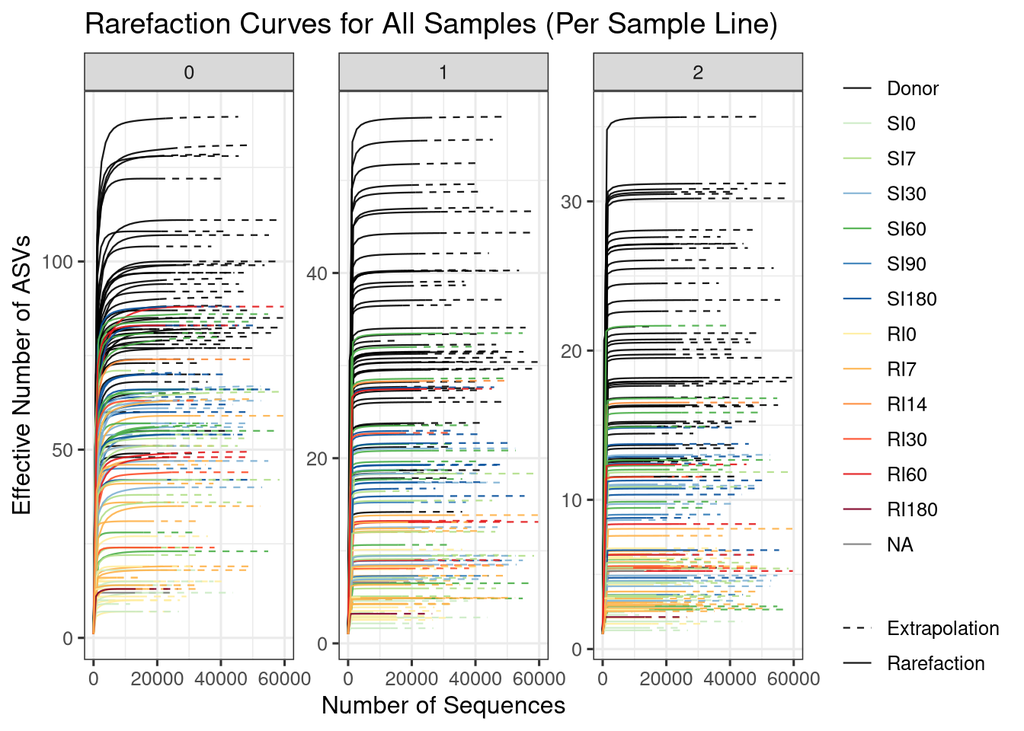

```r
# Prepare plot data
iNEXT_df <- iNEXT_data_group$iNextEst$size_based %>%
  filter(!is.na(SampleName), !is.na(Group)) %>%
  arrange(Group, SampleName, Order.q, m)

# Set factor levels for proper legend ordering
iNEXT_df$Group <- factor(iNEXT_df$Group, levels = group_levels)

# Plot with one line per sample
ggplot(iNEXT_df, aes(x = m, y = qD,
                     group = interaction(SampleName, Method),
                     color = Group, linetype = Method)) +
  geom_line(size = 0.4, alpha = 0.9) +
  facet_wrap(~ Order.q, scales = "free_y") +
  scale_color_manual(values = group_colors) +
  scale_linetype_manual(values = c("Rarefaction" = "solid", "Extrapolation" = "dashed")) +
  scale_x_continuous(limits = c(0, 60000)) +
  theme_bw(base_size = 12) +
  theme(
    legend.position = "right",
    legend.title = element_blank()
  ) +
  labs(
    title = "Rarefaction Curves for All Samples (Per Sample Line)",
    x = "Number of Sequences",
    y = "Effective Number of ASVs"
  )
```

## Manual Rarefaction Curves

```r
# Check the structure of iNEXT grouped data object
str(iNEXT_data_group)
```

```
## List of 3
##  $ DataInfo:'data.frame':    173 obs. of  14 variables:
##   ..$ Assemblage: chr [1:173] "SRR13060060" "SRR13060061" "SRR13060062" "SRR13060065" ...
##   ..$ n         : num [1:173] 15047 45533 18263 11564 16817 ...
##   ..$ S.obs     : num [1:173] 35 40 87 42 31 27 51 23 40 14 ...
##   ..$ SC        : num [1:173] 1 1 1 1 1 ...
##   ..$ f1        : num [1:173] 0 0 2 0 0 0 0 0 0 0 ...
##   ..$ f2        : num [1:173] 0 0 0 0 0 0 1 0 0 0 ...
##   ..$ f3        : num [1:173] 1 0 1 1 0 0 0 0 3 0 ...
##   ..$ f4        : num [1:173] 1 1 0 0 0 1 3 1 0 0 ...
##   ..$ f5        : num [1:173] 0 2 0 0 1 1 1 0 0 0 ...
##   ..$ f6        : num [1:173] 1 3 1 1 0 0 1 1 1 0 ...
##   ..$ f7        : num [1:173] 0 1 1 0 0 1 0 1 0 0 ...
##   ..$ f8        : num [1:173] 1 2 1 0 0 0 0 0 0 0 ...
##   ..$ f9        : num [1:173] 0 0 0 2 0 0 0 0 1 0 ...
##   ..$ f10       : num [1:173] 0 1 1 0 0 1 2 0 0 0 ...
##  $ iNextEst:List of 2
##   ..$ size_based    :'data.frame':   20760 obs. of  12 variables:
##   .. ..$ Assemblage: chr [1:20760] "SRR13060060" "SRR13060060" "SRR13060060" "SRR13060060" ...
##   .. ..$ m         : num [1:20760] 1 836 1672 2508 3344 ...
##   .. ..$ Method    : chr [1:20760] "Rarefaction" "Rarefaction" "Rarefaction" "Rarefaction" ...
##   .. ..$ Order.q   : num [1:20760] 0 0 0 0 0 0 0 0 0 0 ...
##   .. ..$ qD        : num [1:20760] 1 29 31.8 33 33.7 ...
##   .. ..$ qD.LCL    : num [1:20760] 1 28.3 31.1 32.3 33 ...
##   .. ..$ qD.UCL    : num [1:20760] 1 29.6 32.5 33.7 34.4 ...
##   .. ..$ SC        : num [1:20760] 0.47 0.994 0.998 0.999 0.999 ...
##   .. ..$ SC.LCL    : num [1:20760] 0.461 0.994 0.998 0.999 0.999 ...
##   .. ..$ SC.UCL    : num [1:20760] 0.479 0.995 0.998 0.999 1 ...
##   .. ..$ SampleName: chr [1:20760] "A24.2.60_16S" "A24.2.60_16S" "A24.2.60_16S" "A24.2.60_16S" ...
##   .. ..$ Group     : Named chr [1:20760] NA NA NA NA ...
##   .. .. ..- attr(*, "names")= chr [1:20760] "A24.2.60_16S" "A24.2.60_16S" "A24.2.60_16S" "A24.2.60_16S" ...
##   ..$ coverage_based:'data.frame':   11643 obs. of  8 variables:
##   .. ..$ Assemblage: chr [1:11643] "SRR13060060" "SRR13060060" "SRR13060060" "SRR13060060" ...
##   .. ..$ SC        : num [1:11643] 0.47 0.994 0.998 0.999 0.999 ...
##   .. ..$ m         : num [1:11643] 1 836 1672 2508 3344 ...
##   .. ..$ Method    : chr [1:11643] "Rarefaction" "Rarefaction" "Rarefaction" "Rarefaction" ...
##   .. ..$ Order.q   : num [1:11643] 0 0 0 0 0 0 0 0 0 0 ...
##   .. ..$ qD        : num [1:11643] 1 29 31.8 33 33.7 ...
##   .. ..$ qD.LCL    : num [1:11643] 0.989 28.187 31.06 32.321 33.016 ...
##   .. ..$ qD.UCL    : num [1:11643] 1.01 29.72 32.6 33.78 34.39 ...
##  $ AsyEst  :'data.frame':    519 obs. of  7 variables:
##   ..$ Assemblage: chr [1:519] "SRR13060060" "SRR13060060" "SRR13060060" "SRR13060061" ...
##   ..$ Diversity : chr [1:519] "Species richness" "Shannon diversity" "Simpson diversity" "Species richness" ...
##   ..$ Observed  : num [1:519] 35 4.66 2.13 40 5.56 ...
##   ..$ Estimator : num [1:519] 35 4.66 2.13 40 5.56 ...
##   ..$ s.e.      : num [1:519] 0.3458 0.0659 0.0224 0.213 0.0318 ...
##   ..$ LCL       : num [1:519] 35 4.53 2.09 40 5.5 ...
##   ..$ UCL       : num [1:519] 35.68 4.79 2.17 40.42 5.62 ...
##  - attr(*, "class")= chr "iNEXT"
```

```r
# Create plotting dataframe: Hill number estimates for each sample across sequencing depth
iNEXT_manual_df <-
  iNEXT_data_group$iNextEst$size_based %>%
  dplyr::rename(names = Assemblage) %>%  # Rename column for merge
  left_join(metadata_df, by = c("names" = "SampleName")) %>%  # Merge metadata by SampleName
  mutate(Group = factor(Group, levels = group_levels))  # Set factor levels for Group

# Check dimensions and first few rows
dim(iNEXT_manual_df)
```

```
## [1] 20760    63
```

```r
head(iNEXT_manual_df)
```

```
##         names    m      Method Order.q       qD   qD.LCL   qD.UCL        SC
## 1 SRR13060060    1 Rarefaction       0  1.00000  1.00000  1.00000 0.4696243
## 2 SRR13060060  836 Rarefaction       0 28.95116 28.34340 29.55891 0.9941940
## 3 SRR13060060 1672 Rarefaction       0 31.82808 31.13131 32.52484 0.9979420
## 4 SRR13060060 2508 Rarefaction       0 33.04818 32.34641 33.74996 0.9989748
## 5 SRR13060060 3344 Rarefaction       0 33.70259 33.01597 34.38921 0.9994049
## 6 SRR13060060 4180 Rarefaction       0 34.10268 33.43744 34.76793 0.9996159
##      SC.LCL    SC.UCL   SampleName Group ReleaseDate LoadDate spots bases
## 1 0.4605521 0.4786965 A24.2.60_16S  <NA>        <NA>     <NA>    NA    NA
## 2 0.9937856 0.9946025 A24.2.60_16S  <NA>        <NA>     <NA>    NA    NA
## 3 0.9977126 0.9981714 A24.2.60_16S  <NA>        <NA>     <NA>    NA    NA
## 4 0.9987956 0.9991540 A24.2.60_16S  <NA>        <NA>     <NA>    NA    NA
## 5 0.9992619 0.9995480 A24.2.60_16S  <NA>        <NA>     <NA>    NA    NA
## 6 0.9994954 0.9997363 A24.2.60_16S  <NA>        <NA>     <NA>    NA    NA
##   spots_with_mates avgLength size_MB AssemblyName download_path Experiment
```

[output cut: 55 more lines]

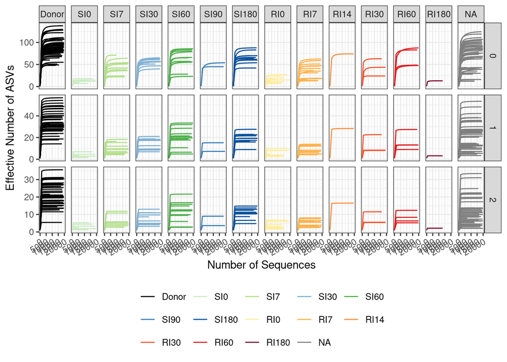

```r
# Set Group factor levels to control legend order
group_levels <- c(
  "Donor", "NA",
  "SI0", "SI7", "SI30", "SI60", "SI90", "SI180",
  "RI0", "RI7", "RI14", "RI30", "RI60", "RI90", "RI180"
)
iNEXT_manual_df$Group <- factor(iNEXT_manual_df$Group, levels = group_levels)

# Reorder group_colors to match the levels above exactly
group_colors_ordered <- group_colors[group_levels]

# Plot with legend broken into 3 rows and color order matching factor levels
iNEXT_manual_df %>%
  filter(Method == "Rarefaction") %>%  # Only keep rarefaction curves
  ggplot(aes(x = m, y = qD, color = Group, group = names)) +
  geom_line(size = 0.5) +  # Draw line
  facet_grid(Order.q ~ Group, scales = "free_y") +  # Facet by q and Group
  scale_color_manual(values = group_colors_ordered) +  # Match color order
  theme_bw() +
  labs(
    y = "Effective Number of ASVs",
    x = "Number of Sequences"
  ) +
  scale_x_continuous(limits = c(0, 20000)) +
  theme(
    axis.text.x = element_text(angle = 30, hjust = 1),
    legend.position = "bottom",
    legend.title = element_blank(),
    legend.text = element_text(size = 9),
    legend.box = "horizontal",
    legend.justification = "center"
  ) +
  guides(color = guide_legend(nrow = 3, byrow = TRUE))
```

INTERPRETATION #1: The rarefaction curves for most samples are stable at all Hill numbers (q = 0, 1, 2), indicating sufficient sequencing depth. When q = 0, species richness can be confidently compared between samples. When q = 1 and q = 2, the curves stabilize earlier, indicating robust detection of common and dominant taxa.

# Shapiro-Wilk

```r
# Check if richness (q = 0) is normally distributed across treatment groups

# Filter iNEXT results to get observed richness values (q = 0)
obs_div_df <-
  iNEXT_manual_df %>%
  dplyr::filter(Method == "Observed", Order.q == 0)

# Quick inspection of the structure
glimpse(obs_div_df)
```

```
## Rows: 173
## Columns: 63
## $ names                 <chr> "SRR13060060", "SRR13060061", "SRR13060062", "SR…
## $ m                     <dbl> 15047, 45533, 18263, 11564, 16817, 17947, 22631,…
## $ Method                <chr> "Observed", "Observed", "Observed", "Observed", …
## $ Order.q               <dbl> 0, 0, 0, 0, 0, 0, 0, 0, 0, 0, 0, 0, 0, 0, 0, 0, …
## $ qD                    <dbl> 35, 40, 87, 42, 31, 27, 51, 23, 40, 14, 102, 84,…
## $ qD.LCL                <dbl> 34.46288, 39.46288, 85.32190, 41.46288, 30.72282…
## $ qD.UCL                <dbl> 35.53712, 40.53712, 88.67810, 42.53712, 31.27718…
## $ SC                    <dbl> 1.0000000, 1.0000000, 0.9998905, 1.0000000, 1.00…
## $ SC.LCL                <dbl> 0.9999688, 0.9999897, 0.9997894, 0.9999760, 1.00…
## $ SC.UCL                <dbl> 1.0000000, 1.0000000, 0.9999916, 1.0000000, 1.00…
## $ SampleName            <chr> "A24.2.60_16S", "A24.2.30_16S", "A24.2.180_16S",…
## $ Group                 <fct> NA, NA, NA, NA, RI7, RI0, SI7, SI60, SI30, SI0, …
## $ ReleaseDate           <dttm> NA, NA, NA, NA, NA, NA, NA, NA, NA, NA, NA, NA,…
```

[output cut: 50 more lines]

```r
# Shapiro-Wilk test for all samples together
richness_shapiro <- shapiro.test(obs_div_df$qD)
print(richness_shapiro)
```

```
##
##  Shapiro-Wilk normality test
##
## data:  obs_div_df$qD
## W = 0.97488, p-value = 0.003164
```

# Statistically Test Richness all groups

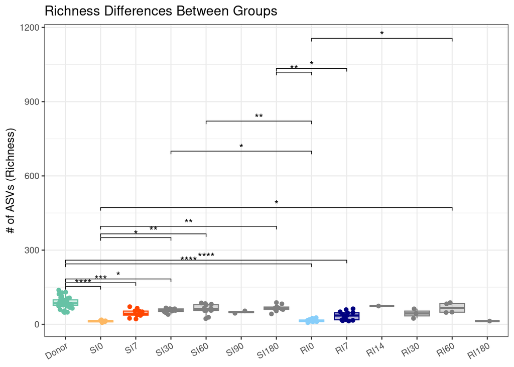

```r
group_colors_with_donor <- c(
  "Donor" = "#66C2A5",
  "RI0" = "#87CEFA",
  "RI7" = "#000080",
  "SI0" = "#FDB863",
  "SI7" = "#FF4500"
)

obs_rich_df <-
  iNEXT_manual_df %>%
  filter(Method == "Observed", Order.q == 0, !is.na(Group)) %>%
  droplevels()

# Kruskal-Wallis
kw_test <- obs_rich_df %>%
  kruskal_test(qD ~ Group)

# Dunn
dunn_result <- obs_rich_df %>%
  dunn_test(qD ~ Group, p.adjust.method = "fdr") %>%
  add_xy_position(x = "Group")

# Plot
rich_ggboxplot <-
  ggboxplot(obs_rich_df, x = "Group", y = "qD",
            color = "Group", fill = "Group", alpha = 0.3,
            outlier.shape = NA) +
  geom_jitter(aes(color = Group), width = 0.2, size = 1.5) +
  scale_color_manual(values = group_colors_with_donor) +
  scale_fill_manual(values = group_colors_with_donor) +
  labs(y = "# of ASVs (Richness)", title = "Richness Differences Between Groups") +
  stat_pvalue_manual(dunn_result, hide.ns = TRUE, tip.length = 0.01) +
  theme_bw() +
  theme(
    legend.position = "none",
    axis.title.x = element_blank(),
    axis.text.x = element_text(angle = 30, hjust = 1, vjust = 1)
  )
print(rich_ggboxplot)
```

# Statistically Test Richness donor RI0/7 SI0/7

```r
# Extract observed richness values (q = 0)
obs_rich_df <-
  iNEXT_manual_df %>%
  dplyr::filter(Group %in% c("Donor", "SI0", "SI7", "RI0", "RI7")) %>%
  dplyr::mutate(Group = factor(Group, levels = c("Donor", "SI0", "SI7", "RI0", "RI7"))) %>%
  dplyr::filter(Method == "Observed", Order.q == 0)

# Test for significant richness differences across groups (non-parametric)
kw_test <- obs_rich_df %>%
  kruskal_test(qD ~ Group)

print(kw_test)
```

```
## # A tibble: 1 × 6
##   .y.       n statistic    df        p method
## * <chr> <int>     <dbl> <int>    <dbl> <chr>
## 1 qD       87      67.7     4 7.03e-14 Kruskal-Wallis
```

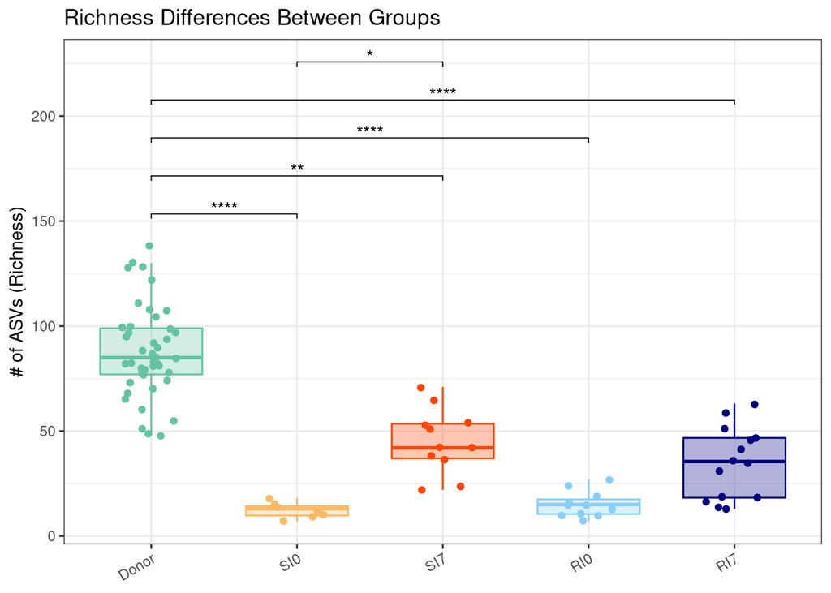

```r
# Pairwise comparisons using Dunn test with FDR adjustment
dunn_result <- obs_rich_df %>%
  dunn_test(qD ~ Group, p.adjust.method = "fdr") %>%
  add_xy_position(x = "Group")

# Richness boxplot by Group
rich_plot <-
  ggboxplot(obs_rich_df, x = "Group", y = "qD",
          color = "Group", fill = "Group", alpha = 0.3,
          outlier.shape = NA) +
  geom_jitter(aes(color = Group), width = 0.2, size = 1.5) +
  scale_color_manual(values = group_colors_with_donor) +
  scale_fill_manual(values = group_colors_with_donor) +
  labs(y = "# of ASVs (Richness)", title = "Richness Differences Between Groups") +
  stat_pvalue_manual(dunn_result, hide.ns = TRUE, tip.length = 0.01, step.increase = 0.01, bracket.nudge.y = 1) +
  theme_bw() +
  theme(
    legend.position = "none",
    axis.title.x = element_blank(),
    axis.text.x = element_text(angle = 30, hjust = 1, vjust = 1)
  )
print(rich_plot)
```

# Statistically Test Shannon donor RI0/7 SI0/7

```r
# Extract observed richness values (q = 1)
obs_rich_df <-
  iNEXT_manual_df %>%
  dplyr::filter(Group %in% c("Donor", "SI0", "SI7", "RI0", "RI7")) %>%
  dplyr::mutate(Group = factor(Group, levels = c("Donor", "SI0", "SI7", "RI0", "RI7"))) %>%
  dplyr::filter(Method == "Observed", Order.q == 1)

# Test for significant richness differences across groups (non-parametric)
kw_test <- obs_rich_df %>%
  kruskal_test(qD ~ Group)

print(kw_test)
```

```
## # A tibble: 1 × 6
##   .y.       n statistic    df        p method
## * <chr> <int>     <dbl> <int>    <dbl> <chr>
## 1 qD       87      67.7     4 6.88e-14 Kruskal-Wallis
```

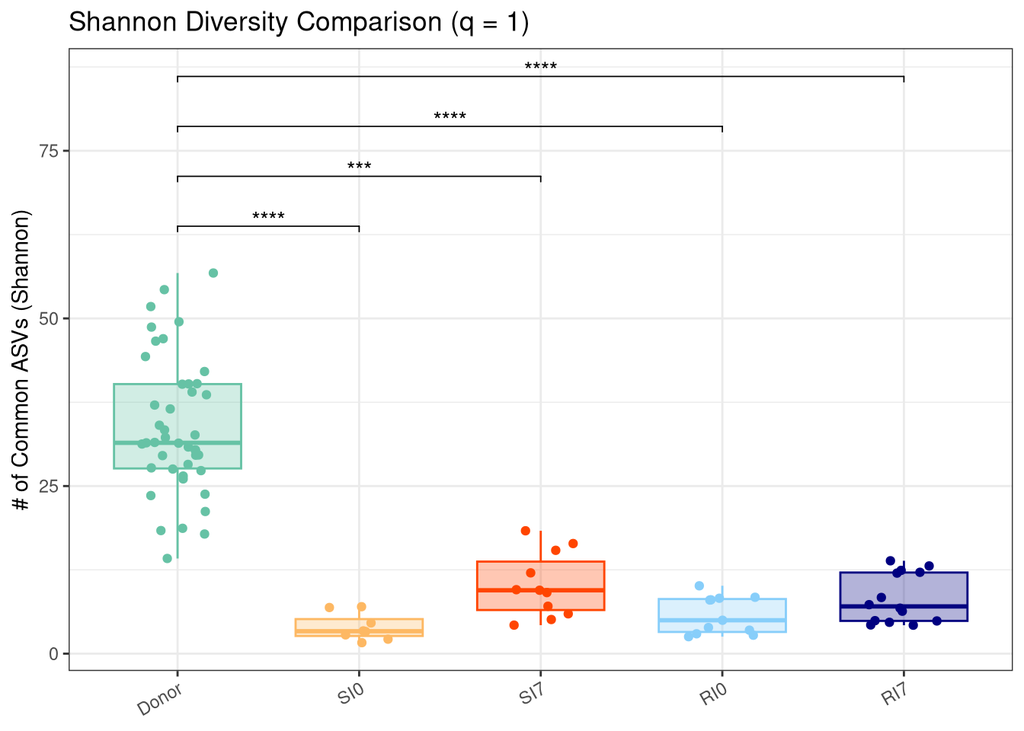

```r
# Pairwise comparisons using Dunn test with FDR adjustment
dunn_result <- obs_rich_df %>%
  dunn_test(qD ~ Group, p.adjust.method = "fdr") %>%
  add_xy_position(x = "Group")

# Shannon plot by Group
shannon_plot <-
  ggboxplot(obs_rich_df, x = "Group", y = "qD",
          color = "Group", fill = "Group", alpha = 0.3,
          outlier.shape = NA) +
  geom_jitter(aes(color = Group), width = 0.2, size = 1.5) +
  scale_color_manual(values = group_colors_with_donor) +
  scale_fill_manual(values = group_colors_with_donor) +
  labs(title = "Shannon Diversity Comparison (q = 1)", y = "# of Common ASVs (Shannon)") +
  stat_pvalue_manual(dunn_result, hide.ns = TRUE, tip.length = 0.01, step.increase = 0.01, bracket.nudge.y = 1) +
  theme_bw() +
  theme(
    legend.position = "none",
    axis.title.x = element_blank(),
    axis.text.x = element_text(angle = 30, hjust = 1, vjust = 1)
  )
print(shannon_plot)
```

# Statistically Test Simpson donor RI0/7 SI0/7

```r
# Extract observed richness values (q = 2)
obs_rich_df <-
  iNEXT_manual_df %>%
  dplyr::filter(Group %in% c("Donor", "SI0", "SI7", "RI0", "RI7")) %>%
  dplyr::mutate(Group = factor(Group, levels = c("Donor", "SI0", "SI7", "RI0", "RI7"))) %>%
  dplyr::filter(Method == "Observed", Order.q == 2)

# Test for significant richness differences across groups (non-parametric)
kw_test <- obs_rich_df %>%
  kruskal_test(qD ~ Group)

print(kw_test)
```

```
## # A tibble: 1 × 6
##   .y.       n statistic    df        p method
## * <chr> <int>     <dbl> <int>    <dbl> <chr>
## 1 qD       87      64.8     4 2.79e-13 Kruskal-Wallis
```

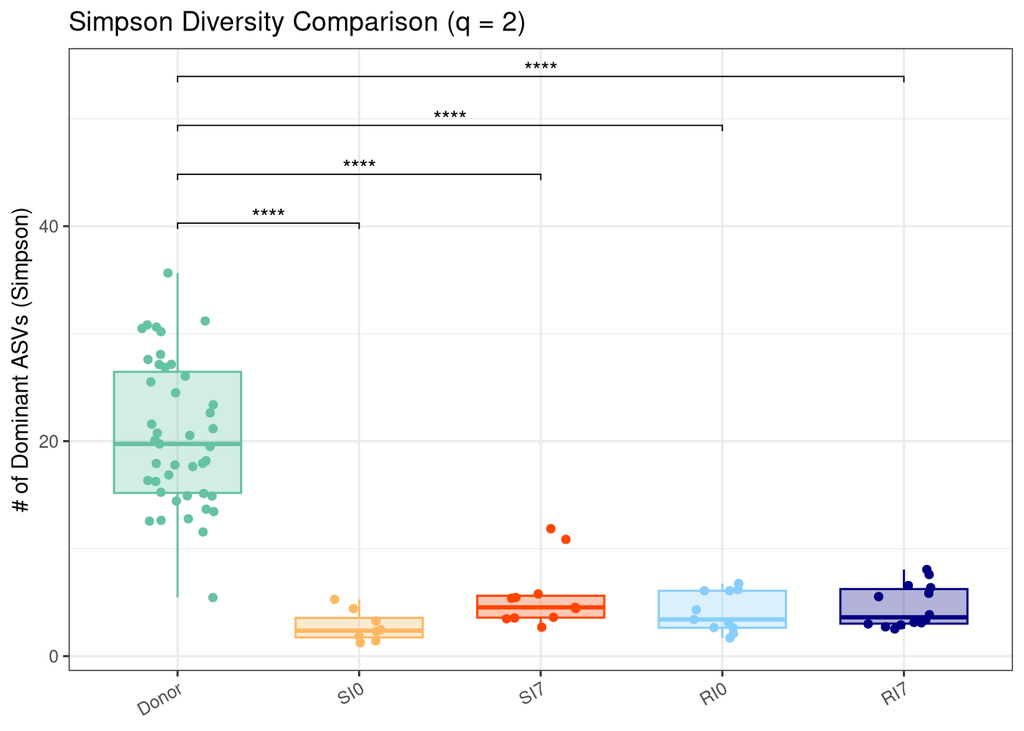

```r
# Pairwise comparisons using Dunn test with FDR adjustment
dunn_result <- obs_rich_df %>%
  dunn_test(qD ~ Group, p.adjust.method = "fdr") %>%
  add_xy_position(x = "Group")

# simpson plot by Group
simpson_plot <-
  ggboxplot(obs_rich_df, x = "Group", y = "qD",
          color = "Group", fill = "Group", alpha = 0.3,
          outlier.shape = NA) +
  geom_jitter(aes(color = Group), width = 0.2, size = 1.5) +
  scale_color_manual(values = group_colors_with_donor) +
  scale_fill_manual(values = group_colors_with_donor) +
  labs(y = "# of Dominant ASVs (Simpson)", title = "Simpson Diversity Comparison (q = 2)") +
  stat_pvalue_manual(dunn_result, hide.ns = TRUE, tip.length = 0.01, step.increase = 0.01, bracket.nudge.y = 1) +
  theme_bw() +
  theme(
    legend.position = "none",
    axis.title.x = element_blank(),
    axis.text.x = element_text(angle = 30, hjust = 1, vjust = 1)
  )
print(simpson_plot)
```

## Plot 3 box plots

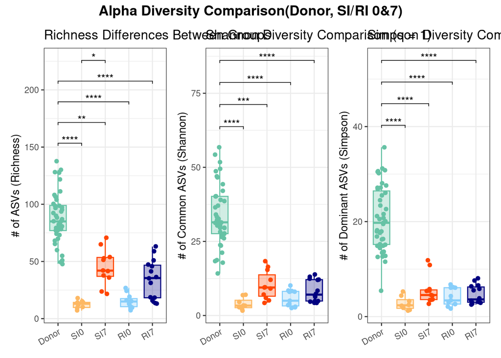

```r
# Combine richness, Shannon, and Simpson diversity plots in one row
rich_plot + shannon_plot + simpson_plot +
  patchwork::plot_annotation(
    title = "Alpha Diversity Comparison(Donor, SI/RI 0&7)",
    theme = theme(plot.title = element_text(hjust = 0.5, size = 14, face = "bold")))
```

We applied Kruskal-Wallis tests for each Hill number (q = 0, 1, 2) to assess group-level differences;

When global significance was detected, we performed Dunn post hoc tests to identify specific group comparisons;

All p-values were adjusted for multiple comparisons using the FDR (False Discovery Rate) method;

We visualized the results with boxplots annotated with significance levels.

We chose non-parametric tests (Kruskal-Wallis and Dunn) because normality tests (e.g., Shapiro-Wilk) showed the diversity data were not normally distributed, making ANOVA inappropriate.

# Final info for Reproducibility

## Check Render Time

```r
# Take the time now that we are at the end of the script
end_time <- Sys.time()
end_time
```

```
## [1] "2025-04-29 12:36:52 EDT"
```

```r
# Echo the elapsed time
elapsed_time <- round((end_time - start_time), 3)
elapsed_time
```

```
## Time difference of 15.101 secs
```